# Loan Data from Propser by Tan Kwok Wee

# Summary of data

```r
length(ld)
```

```
## [1] 83
```

```r
length(ld$ListingKey)
```

```
## [1] 113937
```

```r
str(ld)
```

```
## 'data.frame':    113937 obs. of  83 variables:
##  $ ListingKey                         : Factor w/ 113066 levels "00003546482094282EF90E5",..: 7180 7193 6647 6669 6686 6689 6699 6706 6687 6687 ...
##  $ ListingNumber                      : int  193129 1209647 81716 658116 909464 1074836 750899 768193 1023355 1023355 ...
##  $ ListingCreationDate                : Factor w/ 113064 levels "2005-11-09 20:44:28.847000000",..: 14184 111894 6429 64760 85967 100310 72556 74019 97834 97834 ...
##  $ CreditGrade                        : Factor w/ 9 levels "","A","AA","B",..: 5 1 8 1 1 1 1 1 1 1 ...
##  $ Term                               : int  36 36 36 36 36 60 36 36 36 36 ...
##  $ LoanStatus                         : Factor w/ 12 levels "Cancelled","Chargedoff",..: 3 4 3 4 4 4 4 4 4 4 ...
##  $ ClosedDate                         : Factor w/ 2803 levels "","2005-11-25 00:00:00",..: 1138 1 1263 1 1 1 1 1 1 1 ...
##  $ BorrowerAPR                        : num  0.165 0.12 0.283 0.125 0.246 ...
##  $ BorrowerRate                       : num  0.158 0.092 0.275 0.0974 0.2085 ...
##  $ LenderYield                        : num  0.138 0.082 0.24 0.0874 0.1985 ...
##  $ EstimatedEffectiveYield            : num  NA 0.0796 NA 0.0849 0.1832 ...
##  $ EstimatedLoss                      : num  NA 0.0249 NA 0.0249 0.0925 ...
##  $ EstimatedReturn                    : num  NA 0.0547 NA 0.06 0.0907 ...
##  $ ProsperRating..numeric.            : int  NA 6 NA 6 3 5 2 4 7 7 ...
```

[output cut: 69 more lines]

```r
summary(ld)
```

```
##                    ListingKey     ListingNumber
##  17A93590655669644DB4C06:     6   Min.   :      4
##  349D3587495831350F0F648:     4   1st Qu.: 400919
##  47C1359638497431975670B:     4   Median : 600554
##  8474358854651984137201C:     4   Mean   : 627886
##  DE8535960513435199406CE:     4   3rd Qu.: 892634
##  04C13599434217079754AEE:     3   Max.   :1255725
##  (Other)                :113912
##                     ListingCreationDate  CreditGrade         Term
##  2013-10-02 17:20:16.550000000:     6          :84984   Min.   :12.00
##  2013-08-28 20:31:41.107000000:     4   C      : 5649   1st Qu.:36.00
##  2013-09-08 09:27:44.853000000:     4   D      : 5153   Median :36.00
##  2013-12-06 05:43:13.830000000:     4   B      : 4389   Mean   :40.83
##  2013-12-06 11:44:58.283000000:     4   AA     : 3509   3rd Qu.:36.00
##  2013-08-21 07:25:22.360000000:     3   HR     : 3508   Max.   :60.00
##  (Other)                      :113912   (Other): 6745
##                  LoanStatus                  ClosedDate
##  Current              :56576                      :58848
##  Completed            :38074   2014-03-04 00:00:00:  105
##  Chargedoff           :11992   2014-02-19 00:00:00:  100
##  Defaulted            : 5018   2014-02-11 00:00:00:   92
##  Past Due (1-15 days) :  806   2012-10-30 00:00:00:   81
##  Past Due (31-60 days):  363   2013-02-26 00:00:00:   78
##  (Other)              : 1108   (Other)            :54633
##   BorrowerAPR       BorrowerRate     LenderYield
##  Min.   :0.00653   Min.   :0.0000   Min.   :-0.0100
##  1st Qu.:0.15629   1st Qu.:0.1340   1st Qu.: 0.1242
##  Median :0.20976   Median :0.1840   Median : 0.1730
##  Mean   :0.21883   Mean   :0.1928   Mean   : 0.1827
##  3rd Qu.:0.28381   3rd Qu.:0.2500   3rd Qu.: 0.2400
##  Max.   :0.51229   Max.   :0.4975   Max.   : 0.4925
##  NA's   :25
##  EstimatedEffectiveYield EstimatedLoss   EstimatedReturn
##  Min.   :-0.183          Min.   :0.005   Min.   :-0.183
##  1st Qu.: 0.116          1st Qu.:0.042   1st Qu.: 0.074
##  Median : 0.162          Median :0.072   Median : 0.092
##  Mean   : 0.169          Mean   :0.080   Mean   : 0.096
##  3rd Qu.: 0.224          3rd Qu.:0.112   3rd Qu.: 0.117
##  Max.   : 0.320          Max.   :0.366   Max.   : 0.284
##  NA's   :29084           NA's   :29084   NA's   :29084
```

[output cut: 201 more lines]

```
##  Min.   : 0.00000           Min.   :    0.00            Min.   :   1.00
##  1st Qu.: 0.00000           1st Qu.:    0.00            1st Qu.:   2.00
##  Median : 0.00000           Median :    0.00            Median :  44.00
##  Mean   : 0.02346           Mean   :   16.55            Mean   :  80.48
##  3rd Qu.: 0.00000           3rd Qu.:    0.00            3rd Qu.: 115.00
##  Max.   :33.00000           Max.   :25000.00            Max.   :1189.00
##
##  LoanOriginationYear LoanOriginationMonth
##  2013   :34345       January :11395
##  2012   :19553       October :11043
##  2014   :12172       December:10708
##  2008   :11552       February: 9728
##  2007   :11460       November: 9635
##  2011   :11228       August  : 9592
##  (Other):13627       (Other) :51836
```

Next lets investigate, the levels defined for EmployementStatus, CreditGrade,Occupation, loanstatus and range for loanOriginationDate to understand the levels for each variable

```r
levels(ld$EmploymentStatus)
```

```
## [1] ""              "Employed"      "Full-time"     "Not available"
## [5] "Not employed"  "Other"         "Part-time"     "Retired"
## [9] "Self-employed"
```

```r
levels(ld$CreditGrade)
```

```
## [1] ""   "A"  "AA" "B"  "C"  "D"  "E"  "HR" "NC"
```

```r
levels(ld$Occupation)
```

```
##  [1] ""
##  [2] "Accountant/CPA"
##  [3] "Administrative Assistant"
##  [4] "Analyst"
##  [5] "Architect"
##  [6] "Attorney"
##  [7] "Biologist"
##  [8] "Bus Driver"
##  [9] "Car Dealer"
## [10] "Chemist"
## [11] "Civil Service"
## [12] "Clergy"
## [13] "Clerical"
## [14] "Computer Programmer"
## [15] "Construction"
```

[output cut: 53 more lines]

```r
levels(ld$LoanStatus)
```

```
##  [1] "Cancelled"              "Chargedoff"
##  [3] "Completed"              "Current"
##  [5] "Defaulted"              "FinalPaymentInProgress"
##  [7] "Past Due (>120 days)"   "Past Due (1-15 days)"
##  [9] "Past Due (16-30 days)"  "Past Due (31-60 days)"
## [11] "Past Due (61-90 days)"  "Past Due (91-120 days)"
```

```r
range(ld$LoanOriginationDate)
```

```
## [1] "2005-11-15" "2014-03-12"
```

# Univariate Plots Section

I start by checking the loan status of the borrowers in the dataset.

## Loan Status

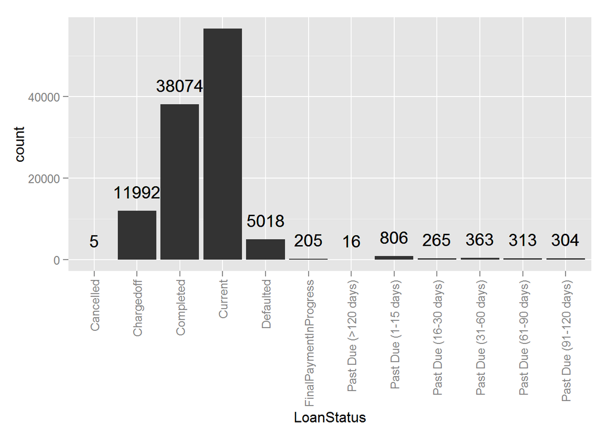

The dataset captures loans taken from 15-Nov-2005 to 12-Mar-2014. In the dataset 56,576 borrowers are servicing the loans and 38,074 completed their loans.

Next, let’s review the loan amount requested.

## Loan Original Amount

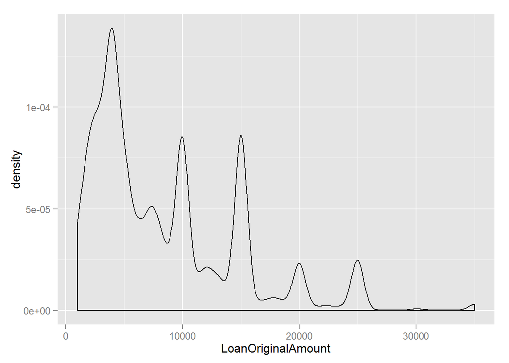

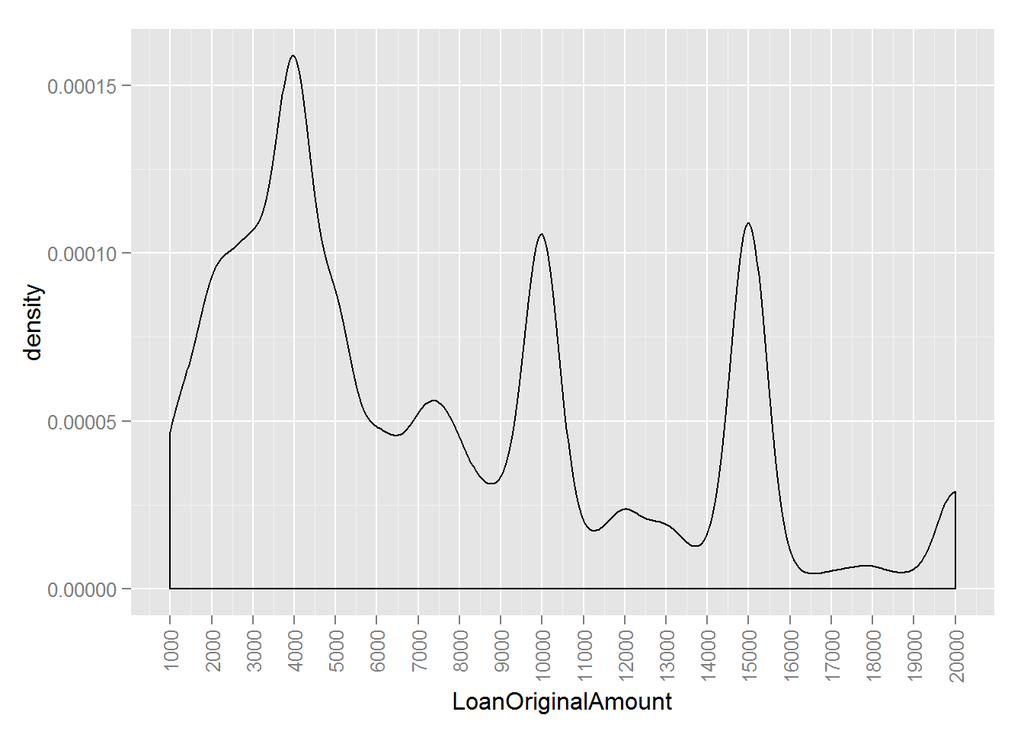

By changing the limiting the x-axis scale, we can see that most loans taken are about $4000, $10000 and $15000. This shows that people like to borrow in round amounts

next, let us understand the borrower rate.

## Borrower Rate

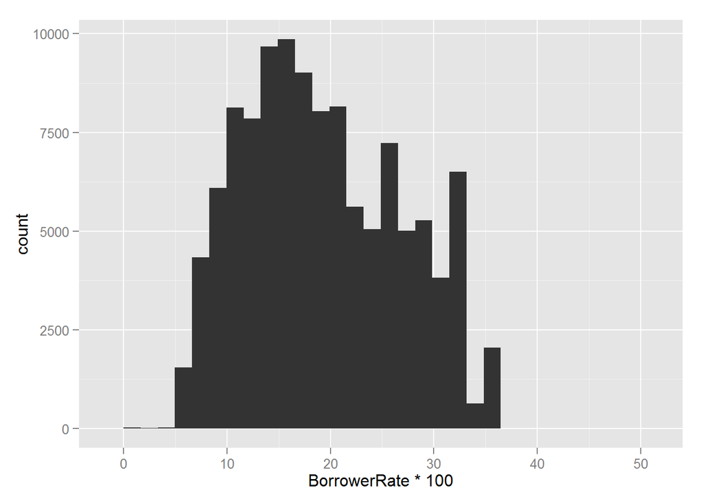

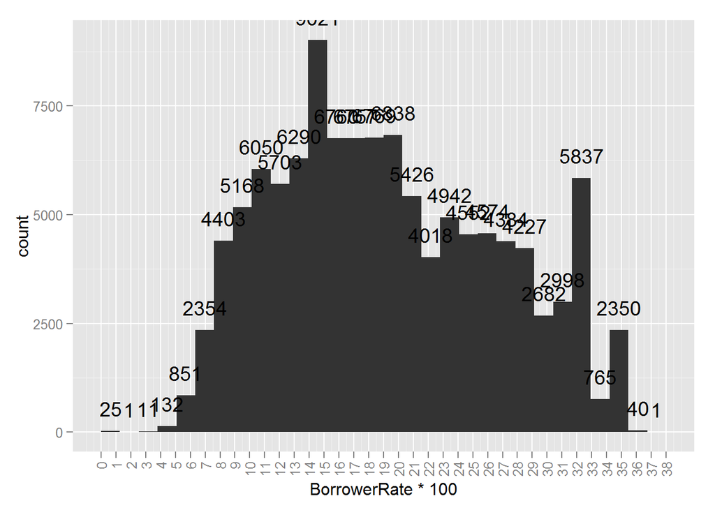

```
##    Min. 1st Qu.  Median    Mean 3rd Qu.    Max.
##  0.0000  0.1340  0.1840  0.1928  0.2500  0.4975
```

let’s check the employment status of the borrowers

## Employment Status

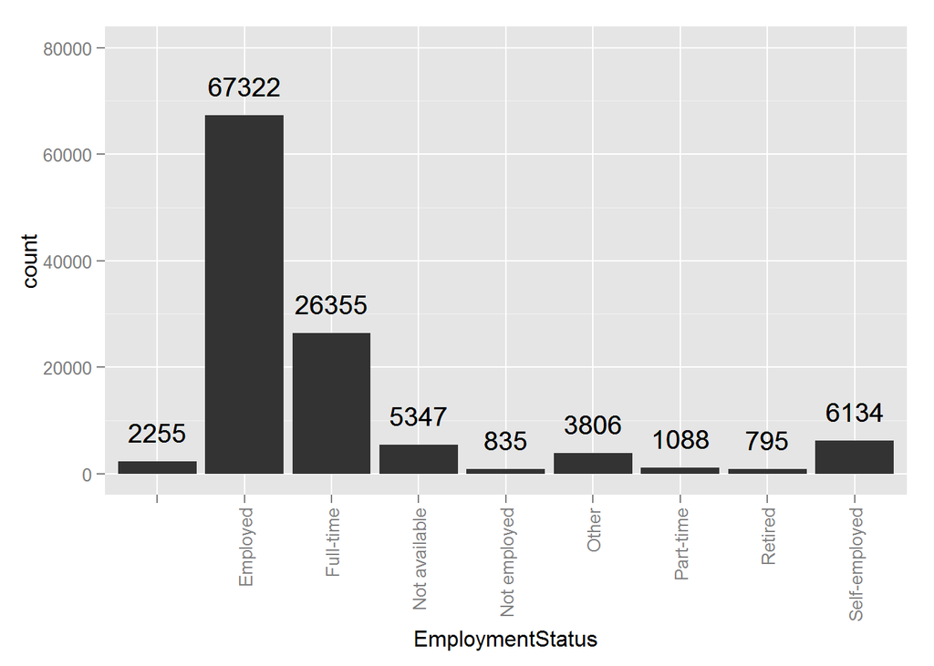

Lets check income range of the borrowers in the dataset.

## Income Range - General

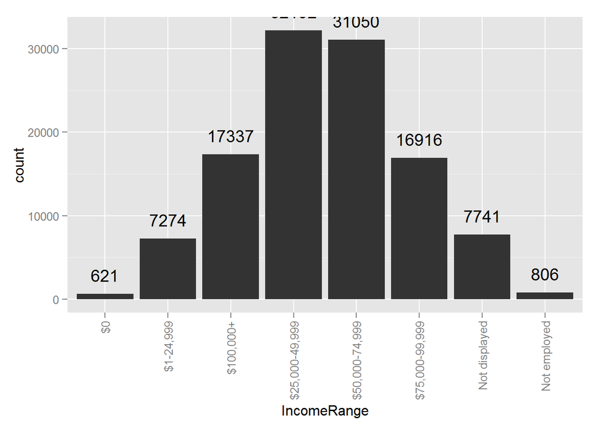

In general,most of the borrower’s income ranges from 25,000 to 75,000. It was suprisingly to see 621 borrowers having $0 income obtaining loans.

next let’s review the monthly stated income

## Stated Monthly Income

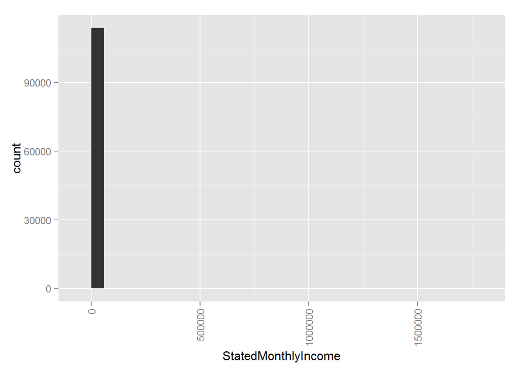

```
##    Min. 1st Qu.  Median    Mean 3rd Qu.    Max.
##       0    3200    4667    5608    6825 1750000
```

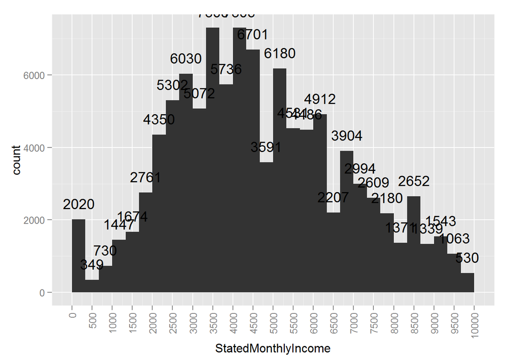

by ignoring the outliers and limiting the x-axis to under 10000. we can now better see the distribution of the monthly income range. Most of the borrowers are having 4000 to 4250 as their monthly income.

next lets check the creditgrade of the borrowers profile.

## Credit Grade

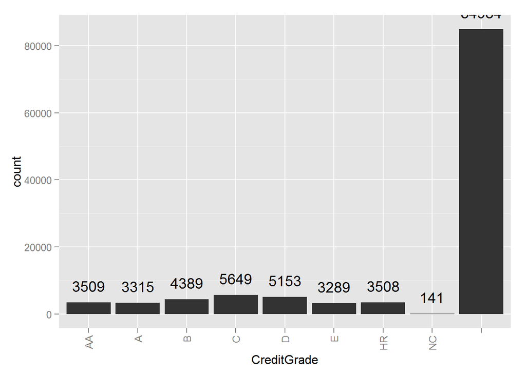

so Lets check the ProsperRating..Alpha., which is the field used after jul-2009 to track borrower’s credit rating

## Prosper Loan Rating Alpha

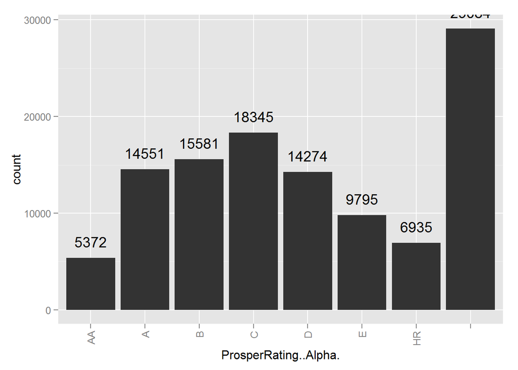

```
##    LoanOriginationDate freq
## 1           2009-07-22    1
## 2           2009-07-28    1
## 3           2009-07-29    1
## 4           2009-07-31    1
## 5           2009-08-03    1
## 6           2009-08-06    1
## 7           2009-08-10    1
## 8           2009-08-12    1
## 9           2009-08-13    2
## 10          2009-08-18    2
## 11          2009-08-19    1
## 12          2009-08-20    1
## 13          2009-08-25    3
## 14          2009-08-26    1
```

[output cut: 85 more lines]

from the plot we can see that The median prosper rating alpha is C. We can see that 29,084 loans are without prosper rating alpha. In total 84,853 borrowers are assigned with prosper rating alpha.

we also can see that there are 99 borrowers are without ProsperRating..Alpha. or Credit Grade, and the occurence is consistently spread over 2009 to 2010.

let us check if the borrowers are over-leveraged by checking debit-to-income ratio

## Debt to Income Ratio

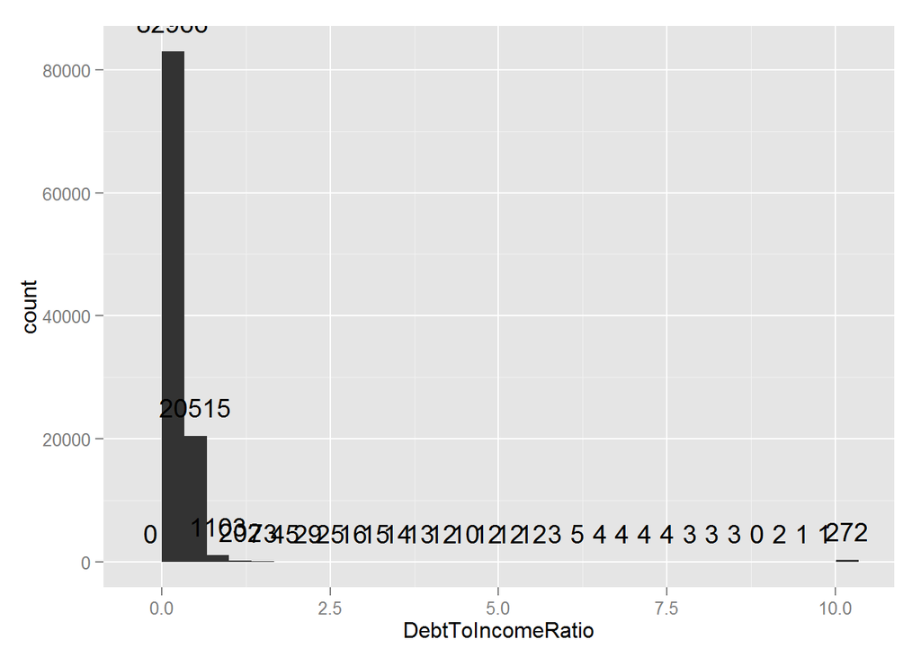

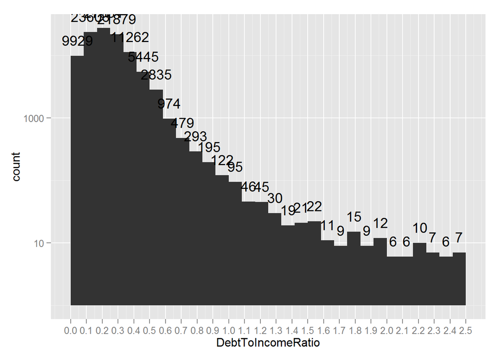

```
##    Min. 1st Qu.  Median    Mean 3rd Qu.    Max.    NA's
##   0.000   0.140   0.220   0.276   0.320  10.010    8554
```

from the plot, we can see that most of the borrowers are having debt to income ratio below 1.0

there are some outlier data, showing that borrowers with debt to income ratio of 10.01.

## Term

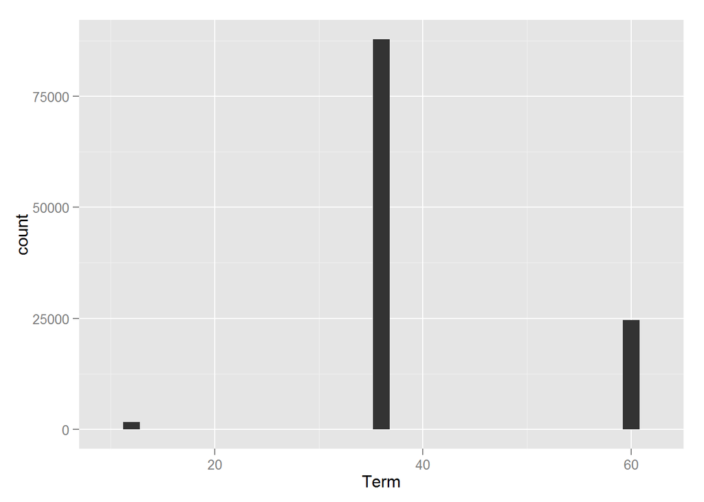

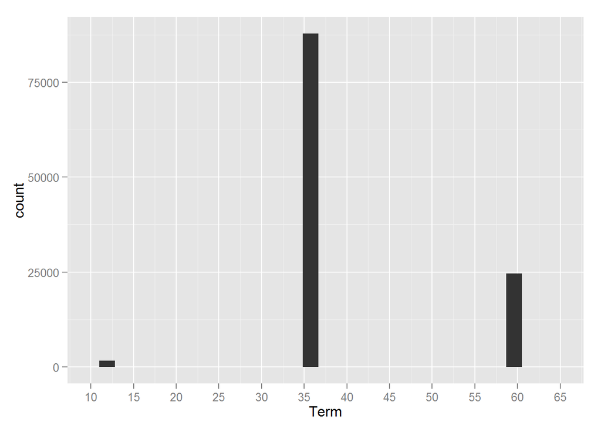

we can see that most of the loans are taken with term of 36 months. lets check when the loans happened

## Loan Origination Year

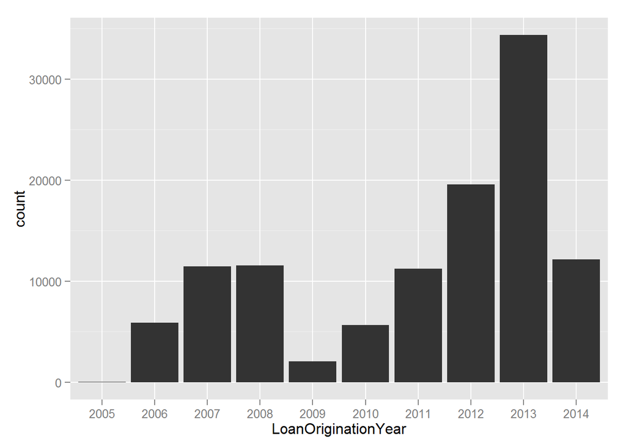

```
##  2005  2006  2007  2008  2009  2010  2011  2012  2013  2014
##    22  5906 11460 11552  2047  5652 11228 19553 34345 12172
```

We can see that there is significant drop in loans taken after 2008. After 2009, more people are taking loans.

let’s check if there is people take more loans in particular months by creating a plot of Loan Oringation Date by formatting the date as month

# Loan Origination Month

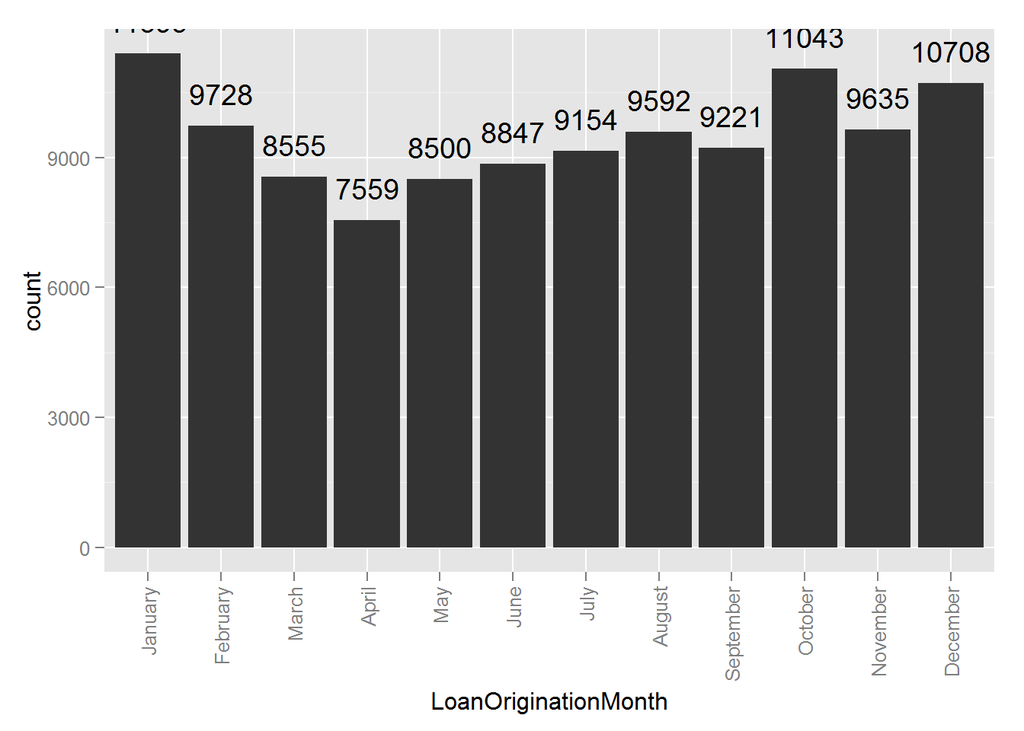

```
##   January  February     March     April       May      June      July
##     11395      9728      8555      7559      8500      8847      9154
##    August September   October  November  December
##      9592      9221     11043      9635     10708
```

We can see that March, April, May has the lowest number of loan taken. Borrowers then to take more loans in Janurary and October. Let’s check if we modify the loan origination date as month-year date format

## Loan Origination Date

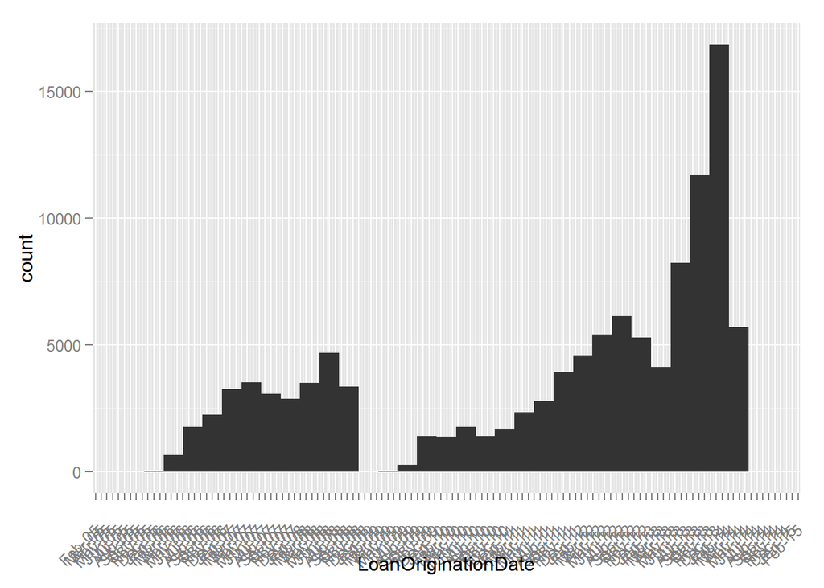

```
## Apr-06 Apr-07 Apr-08 Apr-10 Apr-11 Apr-12 Apr-13 Aug-06 Aug-07 Aug-08
##    288   1098   1305    576    765   1558   1969    769    979   1200
## Aug-09 Aug-10 Aug-11 Aug-12 Aug-13 Dec-05 Dec-06 Dec-07 Dec-09 Dec-10
##    248    430   1087   1819   3060      9    965    849    487    601
## Dec-11 Dec-12 Dec-13 Feb-06 Feb-07 Feb-08 Feb-10 Feb-11 Feb-12 Feb-13
##   1380   1202   5215     73    902    903    357    565   1477    966
## Feb-14 Jan-06 Jan-07 Jan-08 Jan-10 Jan-11 Jan-12 Jan-13 Jan-14 Jul-06
##   4485      8   1017   1050    391    459   1469   1136   5865    550
## Jul-07 Jul-08 Jul-09 Jul-10 Jul-11 Jul-12 Jul-13 Jun-06 Jun-07 Jun-08
##    934   1366     20    464    925   1961   2934    517    950   1436
## Jun-10 Jun-11 Jun-12 Jun-13 Mar-06 Mar-07 Mar-08 Mar-10 Mar-11 Mar-12
##    514    906   1830   2694    234   1160   1121    495    720   1489
## Mar-13 Mar-14 May-06 May-07 May-08 May-09 May-10 May-11 May-12 May-13
##   1514   1822    449   1070   1603     13    449    807   1673   2436
## Nov-05 Nov-06 Nov-07 Nov-09 Nov-10 Nov-11 Nov-12 Nov-13 Oct-06 Oct-07
##     13    698    815    504    539   1330   1400   4336    740    928
## Oct-08 Oct-09 Oct-10 Oct-11 Oct-12 Oct-13 Sep-06 Sep-07 Sep-08 Sep-09
##    532    458    460   1203   1823   4899    615    758   1036    317
## Sep-10 Sep-11 Sep-12 Sep-13
##    376   1081   1852   3186
```

plotting the loan oringination date using month-year format, we can see an increase in loan happened after May 2013. I wonder if there was any specifc event that cause the rapid increase of loans taken?

let check the states where the borrower’s live and their occupation next.

## Borrower State

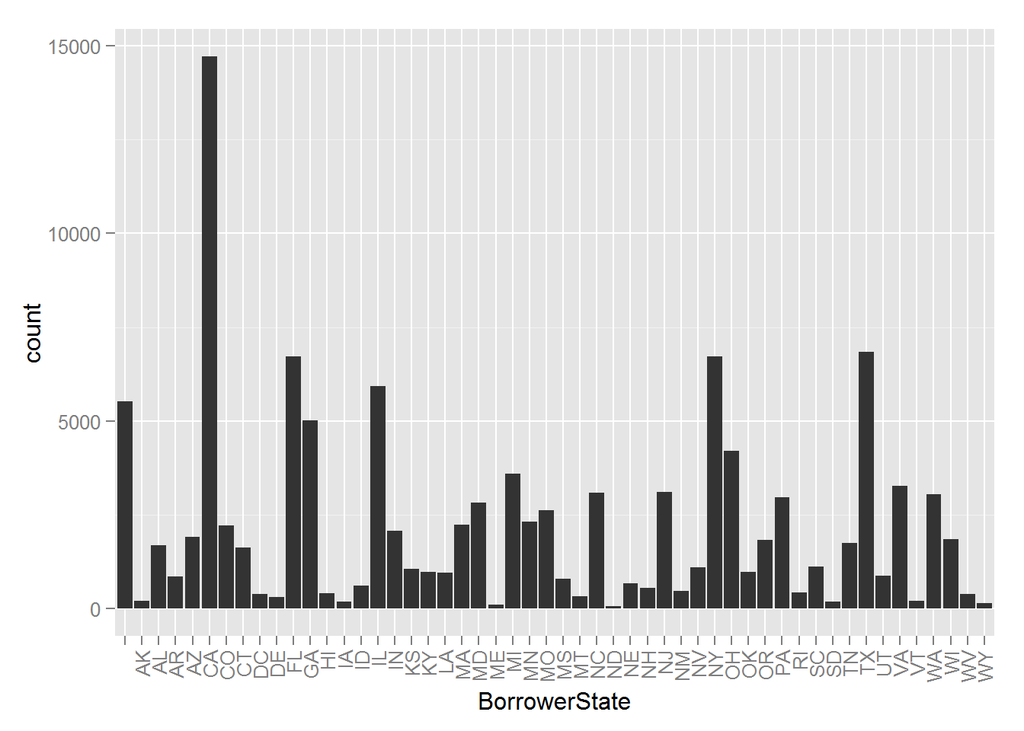

we can see that most of the borrowers live in CA, NY, TX, FL and IL

## Occupation

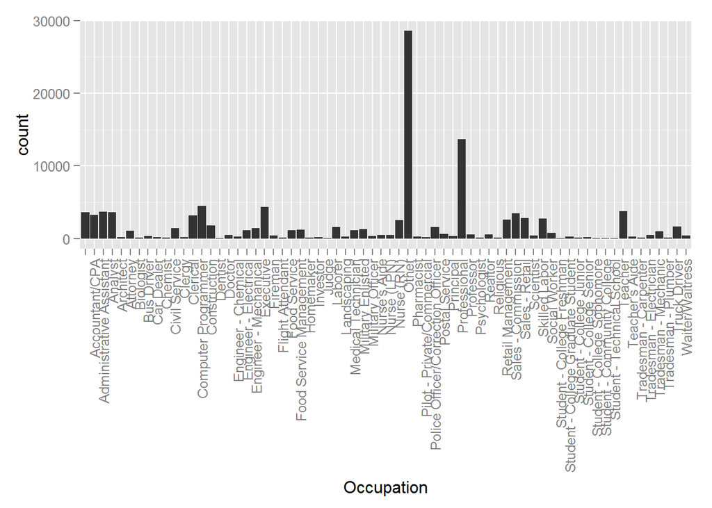

Top 5 borrowers Occupation are professional (13628), computer programmer (4478) and executive (4311), Teacher (3759) and administrative assistant (3588)

let us check what are the top reasons for taking loans

## Listing Category

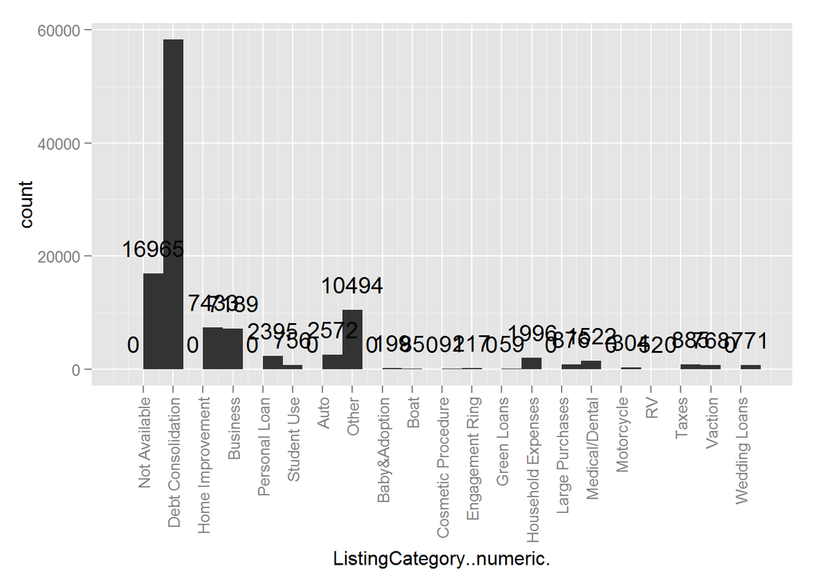

we can see that majority of the loans are for Debt Consolidation (58,308), Others(10,494) and Home Improvement (7,433).

## Total Proper Loans

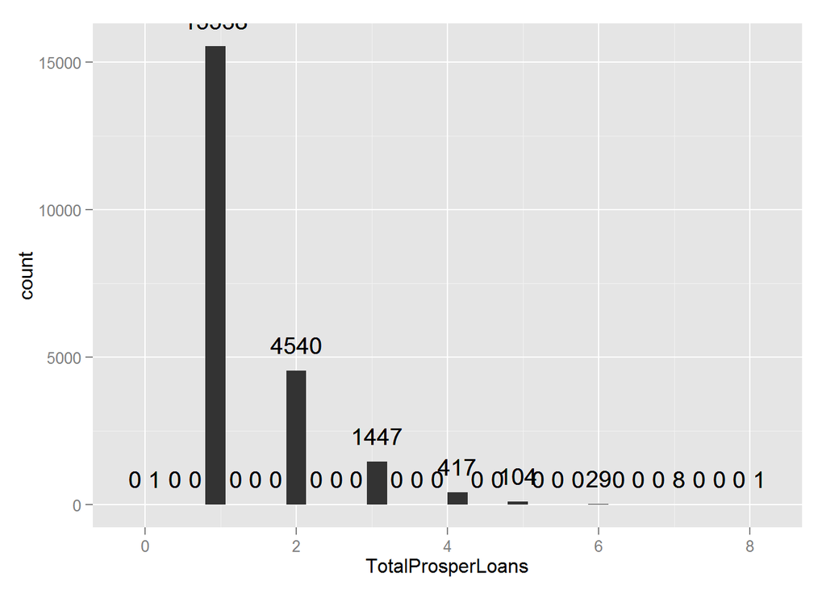

we can understand from the plot that most of the borrowers have only 1 prosper loan.

# Univariate Analysis

### What is the structure of your dataset?

There are 113,937 listings in the dataset with 83 features. I had chosen to analyze the below stated features

LoanOriginalAmount , Credit Grade or ProsperRating..Alpha. , stated monthly income , Debt to Income Ratio , Total Prosper Loans , Current Delinquencies , Delinquencies past 7 years , Borrower Rate , Income Range , LoanOriginationDate , Occupation , Employment Status

below describes the ranking of levels of the features explored

(Worst to Best)

Credit Grade : NC HR E D C B A AA

Income Range : Not employed $0 $1-$24,999 $25,000-$49,999 $50,000 - $74,999 $75,000 - $99,999 $100,000+ Not displayed

ProsperScore Alpha : NC HR E D C B A AA

### What is/are the main feature(s) of interest in your dataset?

The main features of the data set are CreditGrade/Propser Score Alpha, Borrower Rate, Debt to income ratio, Monthly Stated Income and Total prosper loan.

I will want to explore what features will impact the borrower rate.

### What other features in the dataset do you think will help support your investigation into your feature(s) of interest?

I believe related features like Current Delinquencies , Delinquencies past 7 years can help support my investigation

### Did you create any new variables from existing variables in the dataset?

I created variable LoanOriginationYear by formatting the LoanOriginationDate to display year.

I create varaible LoanOriginationMOnth by formatting the LoanOriginationDate to display month.

### Of the features you investigated, were there any unusual distributions? Did you perform any operations on the data to tidy, adjust, or change the form of the data? If so, why did you do this?

I found that feature Loan Orgination date has unusual distribution.

when ploting the Loan Origination month histogram, i can see a slight “concave” distribution. Therefore, i converted the month into month-year date format and re-plotted the histogram. We can now see that the month-year date format depicts distribution skewed towards the right. We can determine that there was an increased amount of loans are taken May 2013

# Bivariate Plots Section

to get an overview of the relationship between identified featuresets, i use ggpairs to generate a summary of plots of features on a small sample size of 10,000 records.

## Correlation Analysis

[figure not shown]

```
##                          DebtToIncomeRatio TotalProsperLoans
## DebtToIncomeRatio             1.0000000000     -0.0023827009
## TotalProsperLoans            -0.0023827009      1.0000000000
## BankcardUtilization           0.0592372795      0.0578504765
## StatedMonthlyIncome          -0.0915920117      0.0083306906
## BorrowerRate                  0.0431485663     -0.0135583310
## LenderYield                   0.0417705975     -0.0128947182
## LoanOriginalAmount            0.0262653572     -0.0409929438
## AmountDelinquent             -0.0210326130      0.0139714657
## DelinquenciesLast7Years      -0.0420527522     -0.0196866995
## RevolvingCreditBalance        0.0344092649      0.0178715329
## OnTimeProsperPayments        -0.0006784497      0.8668332215
## CurrentDelinquencies         -0.0238025079     -0.0324907402
## CurrentCreditLines            0.1017949387      0.1096520997
## ProsperPrincipalBorrowed      0.0003650832      0.8029513281
## PublicRecordsLast10Years     -0.0380748196      0.0002980988
## EstimatedLoss                -0.0043625911      0.0761780219
##                          BankcardUtilization StatedMonthlyIncome
## DebtToIncomeRatio                0.059237279        -0.091592012
## TotalProsperLoans                0.057850476         0.008330691
## BankcardUtilization              1.000000000         0.044373377
## StatedMonthlyIncome              0.044373377         1.000000000
## BorrowerRate                     0.239942213        -0.094469498
## LenderYield                      0.238057549        -0.093319765
## LoanOriginalAmount               0.012790552         0.247847314
## AmountDelinquent                -0.027682928         0.016731934
## DelinquenciesLast7Years         -0.070423024        -0.023012908
## RevolvingCreditBalance           0.288428691         0.207920222
## OnTimeProsperPayments            0.072051255         0.003513457
## CurrentDelinquencies            -0.144494761        -0.043412735
## CurrentCreditLines               0.271574306         0.147473445
## ProsperPrincipalBorrowed         0.028897196         0.056241731
## PublicRecordsLast10Years         0.006014411        -0.020373066
## EstimatedLoss                    0.267054426        -0.013598529
##                          BorrowerRate  LenderYield LoanOriginalAmount
## DebtToIncomeRatio          0.04314857  0.041770598         0.02626536
## TotalProsperLoans         -0.01355833 -0.012894718        -0.04099294
## BankcardUtilization        0.23994221  0.238057549         0.01279055
## StatedMonthlyIncome       -0.09446950 -0.093319765         0.24784731
## BorrowerRate               1.00000000  0.999096577        -0.32174419
```

[output cut: 81 more lines]

```
## TotalProsperLoans          0.076178022
## BankcardUtilization        0.267054426
## StatedMonthlyIncome       -0.013598529
## BorrowerRate               0.665356813
## LenderYield                0.669757203
## LoanOriginalAmount        -0.156040491
## AmountDelinquent           0.036869751
## DelinquenciesLast7Years    0.035859567
## RevolvingCreditBalance     0.004493258
## OnTimeProsperPayments      0.100551282
## CurrentDelinquencies      -0.087371757
## CurrentCreditLines         0.102715665
## ProsperPrincipalBorrowed   0.017490511
## PublicRecordsLast10Years   0.031380880
## EstimatedLoss              1.000000000
```

let’s focus on borrowers income range for borrowers with emmployment status as “not employed” or “no employment status”.

## Income Range - employment status = Not Employed or Not available

```
## [1] ""              "Employed"      "Full-time"     "Not available"
## [5] "Not employed"  "Other"         "Part-time"     "Retired"
## [9] "Self-employed"
```

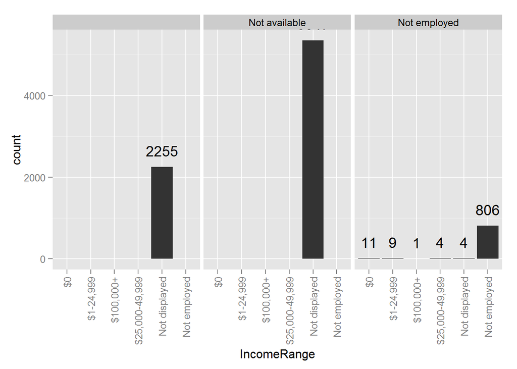

if we subset the data for those borrowers without employment status or not available and or employed, we uncover some interesting details.

there are 11 people in this group declared they have $0 as well as having employment status as not employed obtaining loans.

there are 806 people in this group declared their income range as “not employed”" for income range as well as not employed obtaining loans.

Most of the people with income range status as “Not displayed” come from the group of people declaring their employment status as (no employment status/not available or not employed).

I wanted to know if term changes with the loan amount and decided to do a violin plot to understand the distribution.

## Term vs Loan Original Amount

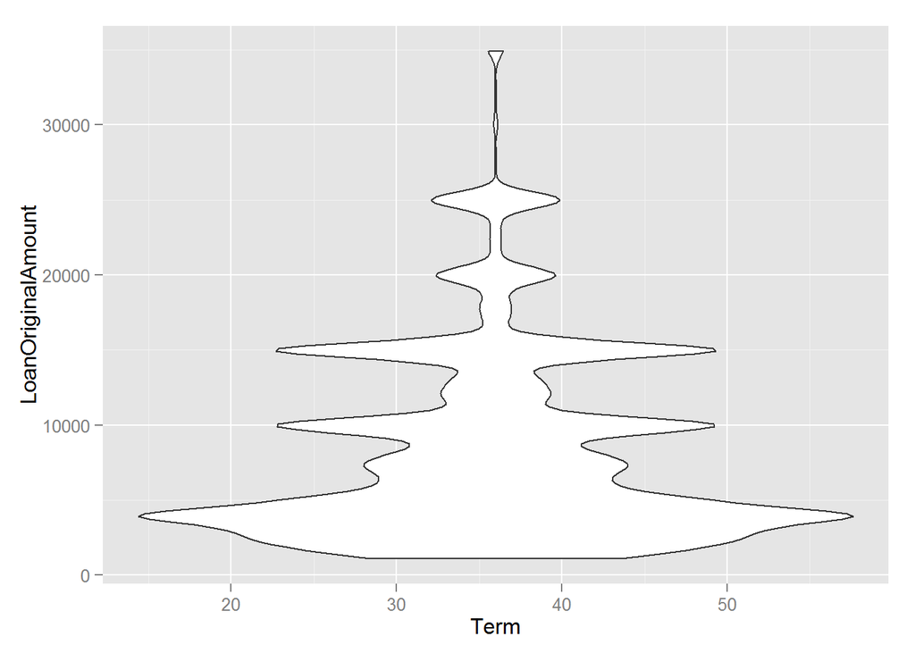

```
##   Term  freq
## 1   12  1614
## 2   36 87778
## 3   60 24545
```

```
##   Term LoanOriginalAmount  freq
## 1   36               4000 12088
## 2   36              10000  7049
## 3   36              15000  6674
## 4   36               5000  6169
## 5   60              15000  5668
## 6   36               2000  5336
```

we can see that for loan amounts under 10,000, the term varies widely. for loans above 30,000, we can see the term varies little.

by constructing a frequency table by term, we can see that most people opt for 36 months loans, followed by 60 months loan.

by constructing a frequency table by term and loan amount, we can see that most people opt for 36 months loans for loan of 4,000 and followed by 36 months loan for loan of 10,000.

## Loan Origination Year Vs Loan Original Amount

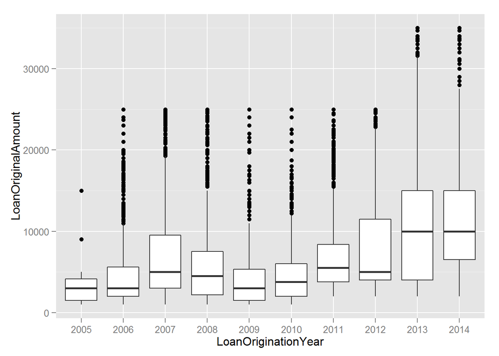

```
##   LoanOriginationYear LoanOriginalAmount freq
## 1                2013              15000 5954
## 2                2013               4000 5869
## 3                2013              10000 5648
## 4                2012               4000 4383
## 5                2014              15000 2441
## 6                2012              15000 2200
```

```
##   LoanOriginationYear LoanOriginalAmount freq
## 1                2008               5000 1153
## 2                2008               1000 1121
## 3                2007               5000 1085
## 4                2008               3000  859
## 5                2007               3000  747
## 6                2007               1000  680
```

We can see that range of loans amount increases after 2011. Most loan amounts requested are 15,000, 4,000 and 10,000 after 2011. Most loan amounts requested are 5000 and 1000 before 2011.

i am curious to understand which state does the bulk of the borrowwers reside in.

## Borrower State

```
##             state  freq
## 5      california 14717
## 43          texas  6842
## 32       new york  6729
## 9         florida  6720
## 13       illinois  5921
## 51           <NA>  5897
## 10        georgia  5008
## 35           ohio  4197
## 22       michigan  3593
## 46       virginia  3278
## 30     new jersey  3097
## 33 north carolina  3084
## 47     washington  3048
## 38   pennsylvania  2972
```

[output cut: 37 more lines]

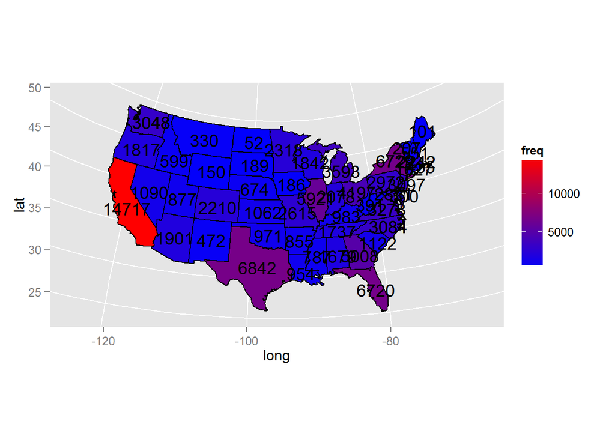

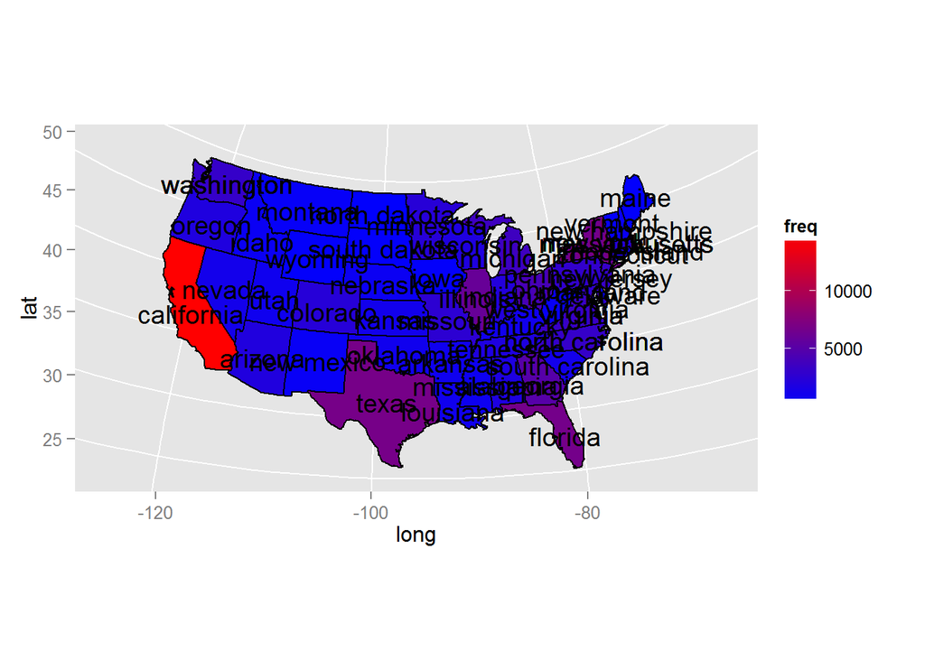

It is clear that the bulk of borrowers live in California, Texas, New York Florida and Illinois.

I am curious to see the distribution of credit grade and loan amounts of borrowers living in California, Texas, New York Florida and Illinois.

## Borrower State ( CA, TX, NY, IL, FL ) and Percentage of CreditGrade

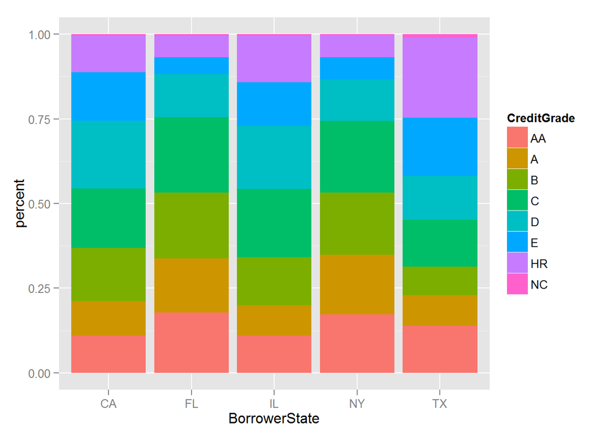

New York has the highest amount of borrowers with credit grade of AA and A, and i suspect that people there has better paying jobs then rest of the states in the histogram.

## Credit Grade vs Loan Original Amount, Proper Rating Alpha vs Loan Amounts

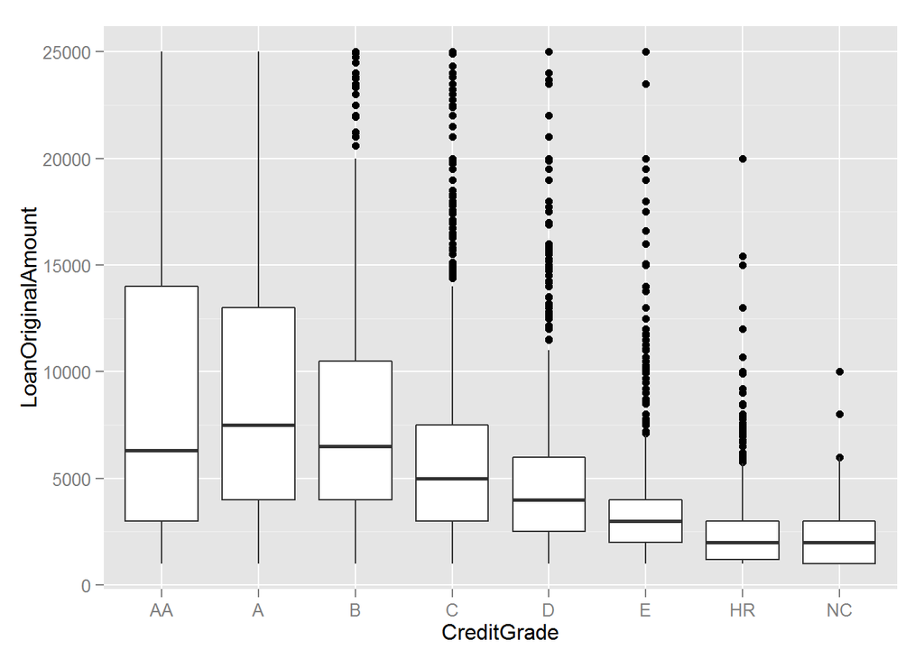

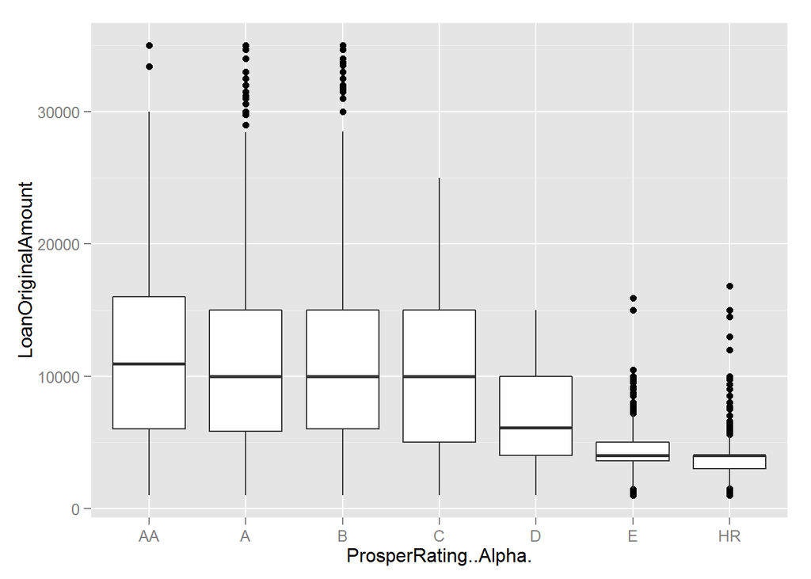

In general, we can confirm that people with higher credit grade will be able to obtain higher loan amounts.